# Risk Factor Analysis

## Outcome Variable

**Outcome Variable:** whz

## Predictor Variables

**Intervention Variable:** mwtkg

**Adjustment Set:**

- arm
- W_mage
- W_fage
- meducyrs
- feducyrs
- single
- brthmon
- W_gagebrth
- W_birthwt
- W_birthlen
- vagbrth
- delta_W_mage
- delta_W_fage
- delta_meducyrs
- delta_feducyrs
- delta_single
- delta_brthmon
- delta_W_gagebrth
- delta_W_birthwt
- delta_W_birthlen
- delta_vagbrth

## Stratifying Variables

The analysis was stratified on these variable(s):

- agecat
- studyid
- country

## Data Summary

| agecat | studyid | country | mwtkg | n_cell | n |
| --- | --- | --- | --- | --- | --- |
| 6 months | ki0047075b-MAL-ED | BANGLADESH | >=58 kg | 46 | 241 |
| 6 months | ki0047075b-MAL-ED | BANGLADESH | <52 kg | 154 | 241 |
| 6 months | ki0047075b-MAL-ED | BANGLADESH | [52-58) kg | 41 | 241 |
| 6 months | ki0047075b-MAL-ED | BRAZIL | >=58 kg | 137 | 208 |
| 6 months | ki0047075b-MAL-ED | BRAZIL | <52 kg | 37 | 208 |
| 6 months | ki0047075b-MAL-ED | BRAZIL | [52-58) kg | 34 | 208 |
| 6 months | ki0047075b-MAL-ED | INDIA | >=58 kg | 40 | 235 |
| 6 months | ki0047075b-MAL-ED | INDIA | <52 kg | 146 | 235 |
| 6 months | ki0047075b-MAL-ED | INDIA | [52-58) kg | 49 | 235 |
| 6 months | ki0047075b-MAL-ED | NEPAL | >=58 kg | 79 | 236 |
| 6 months | ki0047075b-MAL-ED | NEPAL | <52 kg | 75 | 236 |
| 6 months | ki0047075b-MAL-ED | NEPAL | [52-58) kg | 82 | 236 |
| 6 months | ki0047075b-MAL-ED | PERU | >=58 kg | 100 | 272 |
| 6 months | ki0047075b-MAL-ED | PERU | <52 kg | 107 | 272 |
| 6 months | ki0047075b-MAL-ED | PERU | [52-58) kg | 65 | 272 |
| 6 months | ki0047075b-MAL-ED | SOUTH AFRICA | >=58 kg | 179 | 249 |
| 6 months | ki0047075b-MAL-ED | SOUTH AFRICA | <52 kg | 29 | 249 |
| 6 months | ki0047075b-MAL-ED | SOUTH AFRICA | [52-58) kg | 41 | 249 |
| 6 months | ki0047075b-MAL-ED | TANZANIA, UNITED REPUBLIC OF | >=58 kg | 94 | 247 |
| 6 months | ki0047075b-MAL-ED | TANZANIA, UNITED REPUBLIC OF | <52 kg | 95 | 247 |
| 6 months | ki0047075b-MAL-ED | TANZANIA, UNITED REPUBLIC OF | [52-58) kg | 58 | 247 |
| 6 months | ki1000304b-SAS-CompFeed | INDIA | >=58 kg | 99 | 1328 |
| 6 months | ki1000304b-SAS-CompFeed | INDIA | <52 kg | 1016 | 1328 |
| 6 months | ki1000304b-SAS-CompFeed | INDIA | [52-58) kg | 213 | 1328 |
| 6 months | ki1017093-NIH-Birth | BANGLADESH | >=58 kg | 71 | 536 |
| 6 months | ki1017093-NIH-Birth | BANGLADESH | <52 kg | 384 | 536 |
| 6 months | ki1017093-NIH-Birth | BANGLADESH | [52-58) kg | 81 | 536 |
| 6 months | ki1017093b-PROVIDE | BANGLADESH | >=58 kg | 106 | 581 |
| 6 months | ki1017093b-PROVIDE | BANGLADESH | <52 kg | 369 | 581 |
| 6 months | ki1017093b-PROVIDE | BANGLADESH | [52-58) kg | 106 | 581 |

[output cut: 57 more lines]

The following strata were considered:

- agecat: 24 months, studyid: ki0047075b-MAL-ED, country: BANGLADESH
- agecat: 24 months, studyid: ki0047075b-MAL-ED, country: BRAZIL
- agecat: 24 months, studyid: ki0047075b-MAL-ED, country: INDIA
- agecat: 24 months, studyid: ki0047075b-MAL-ED, country: NEPAL
- agecat: 24 months, studyid: ki0047075b-MAL-ED, country: PERU
- agecat: 24 months, studyid: ki0047075b-MAL-ED, country: SOUTH AFRICA
- agecat: 24 months, studyid: ki0047075b-MAL-ED, country: TANZANIA, UNITED REPUBLIC OF
- agecat: 24 months, studyid: ki1017093-NIH-Birth, country: BANGLADESH
- agecat: 24 months, studyid: ki1017093b-PROVIDE, country: BANGLADESH
- agecat: 24 months, studyid: ki1017093c-NIH-Crypto, country: BANGLADESH
- agecat: 24 months, studyid: ki1066203-TanzaniaChild2, country: TANZANIA, UNITED REPUBLIC OF
- agecat: 24 months, studyid: ki1119695-PROBIT, country: BELARUS
- agecat: 24 months, studyid: ki1126311-ZVITAMBO, country: ZIMBABWE
- agecat: 24 months, studyid: ki1148112-LCNI-5, country: MALAWI
- agecat: 6 months, studyid: ki0047075b-MAL-ED, country: BANGLADESH
- agecat: 6 months, studyid: ki0047075b-MAL-ED, country: BRAZIL
- agecat: 6 months, studyid: ki0047075b-MAL-ED, country: INDIA
- agecat: 6 months, studyid: ki0047075b-MAL-ED, country: NEPAL
- agecat: 6 months, studyid: ki0047075b-MAL-ED, country: PERU
- agecat: 6 months, studyid: ki0047075b-MAL-ED, country: SOUTH AFRICA
- agecat: 6 months, studyid: ki0047075b-MAL-ED, country: TANZANIA, UNITED REPUBLIC OF
- agecat: 6 months, studyid: ki1000304b-SAS-CompFeed, country: INDIA
- agecat: 6 months, studyid: ki1017093-NIH-Birth, country: BANGLADESH
- agecat: 6 months, studyid: ki1017093b-PROVIDE, country: BANGLADESH
- agecat: 6 months, studyid: ki1017093c-NIH-Crypto, country: BANGLADESH
- agecat: 6 months, studyid: ki1066203-TanzaniaChild2, country: TANZANIA, UNITED REPUBLIC OF
- agecat: 6 months, studyid: ki1119695-PROBIT, country: BELARUS
- agecat: 6 months, studyid: ki1126311-ZVITAMBO, country: ZIMBABWE
- agecat: 6 months, studyid: ki1148112-LCNI-5, country: MALAWI

### Dropped Strata

Some strata were dropped due to rare outcomes:

- agecat: 24 months, studyid: ki1066203-TanzaniaChild2, country: TANZANIA, UNITED REPUBLIC OF

## Methods Detail

We’re interested in the causal parameters $E[Y_a]$ for all values of $a \in \mathcal{A}$. These parameters represent the mean outcome if, possibly contrary to fact, we intervened to set all units to have $A=a$. Under the randomization and positivity assumptions, these are identified by the statistical parameters $\psi_a=E_W[E_{Y|A,W}(Y|A=a,W)]$. In addition, we’re interested in the mean of $Y$, $E[Y]$ under no intervention (the observed mean). We will estimate these parameters by using SuperLearner to fit the relevant likelihood factors – $E_{Y|A,W}(Y|A=a,W)$ and $p(A=a|W)$, and then updating our likelihood fit using a joint TMLE.

For unadjusted analyses ($W=\{\}$), initial likelihoods were estimated using Lrnr_glm to estimate the simple $E(Y|A)$ and Lrnr_mean to estimate $p(A)$. For adjusted analyses, a small library containing Lrnr_glmnet, Lrnr_xgboost, and Lrnr_mean was used.

Having estimated these parameters, we will then use the delta method to estimate relative risks and attributable risks relative to a prespecified baseline level of $A$.

# Results Detail

## Results Plots

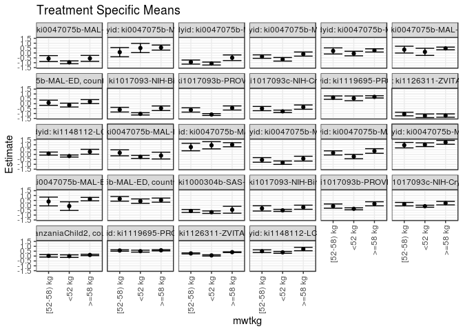

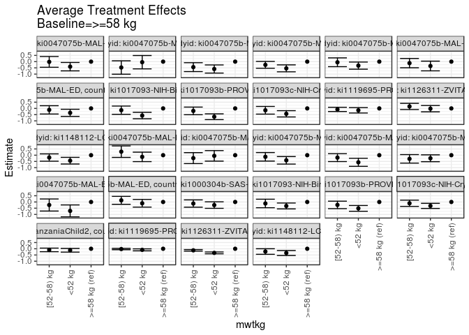

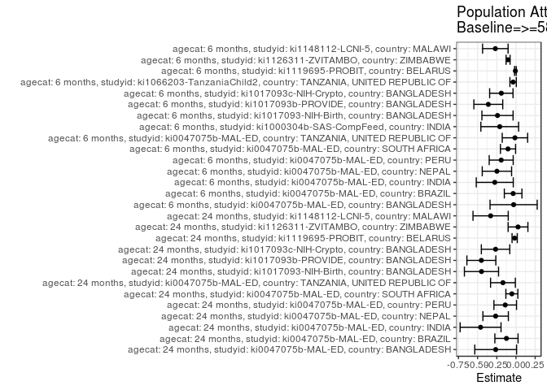

## Results Table

### Parameter: TSM

| agecat | studyid | country | intervention_level | baseline_level | estimate | ci_lower | ci_upper |
| --- | --- | --- | --- | --- | --- | --- | --- |
| 6 months | ki0047075b-MAL-ED | BANGLADESH | >=58 kg | NA | -0.1087568 | -0.4556066 | 0.2380930 |
| 6 months | ki0047075b-MAL-ED | BANGLADESH | <52 kg | NA | -0.2439528 | -0.3973618 | -0.0905438 |
| 6 months | ki0047075b-MAL-ED | BANGLADESH | [52-58) kg | NA | 0.1737076 | -0.1311940 | 0.4786091 |
| 6 months | ki0047075b-MAL-ED | BRAZIL | >=58 kg | NA | 1.0019407 | 0.7927646 | 1.2111167 |
| 6 months | ki0047075b-MAL-ED | BRAZIL | <52 kg | NA | 0.9485045 | 0.5798633 | 1.3171458 |
| 6 months | ki0047075b-MAL-ED | BRAZIL | [52-58) kg | NA | 0.7671495 | 0.3817300 | 1.1525690 |
| 6 months | ki0047075b-MAL-ED | INDIA | >=58 kg | NA | -0.4220146 | -0.6681548 | -0.1758744 |
| 6 months | ki0047075b-MAL-ED | INDIA | <52 kg | NA | -0.8342595 | -1.0099636 | -0.6585554 |
| 6 months | ki0047075b-MAL-ED | INDIA | [52-58) kg | NA | -0.5525634 | -0.7882062 | -0.3169206 |
| 6 months | ki0047075b-MAL-ED | NEPAL | >=58 kg | NA | 0.3596689 | 0.1244762 | 0.5948616 |
| 6 months | ki0047075b-MAL-ED | NEPAL | <52 kg | NA | -0.2097914 | -0.4316821 | 0.0120994 |
| 6 months | ki0047075b-MAL-ED | NEPAL | [52-58) kg | NA | 0.1642497 | -0.0475828 | 0.3760822 |
| 6 months | ki0047075b-MAL-ED | PERU | >=58 kg | NA | 1.2492157 | 1.0525968 | 1.4458346 |
| 6 months | ki0047075b-MAL-ED | PERU | <52 kg | NA | 1.0028738 | 0.8111124 | 1.1946351 |
| 6 months | ki0047075b-MAL-ED | PERU | [52-58) kg | NA | 0.9557317 | 0.6760035 | 1.2354598 |
| 6 months | ki0047075b-MAL-ED | SOUTH AFRICA | >=58 kg | NA | 0.6331339 | 0.4558925 | 0.8103752 |
| 6 months | ki0047075b-MAL-ED | SOUTH AFRICA | <52 kg | NA | -0.0826550 | -0.5261044 | 0.3607944 |
| 6 months | ki0047075b-MAL-ED | SOUTH AFRICA | [52-58) kg | NA | 0.3895311 | -0.0595960 | 0.8386582 |
| 6 months | ki0047075b-MAL-ED | TANZANIA, UNITED REPUBLIC OF | >=58 kg | NA | 0.5309567 | 0.3209163 | 0.7409970 |
| 6 months | ki0047075b-MAL-ED | TANZANIA, UNITED REPUBLIC OF | <52 kg | NA | 0.4255500 | 0.2008324 | 0.6502676 |
| 6 months | ki0047075b-MAL-ED | TANZANIA, UNITED REPUBLIC OF | [52-58) kg | NA | 0.6620993 | 0.4237791 | 0.9004194 |
| 6 months | ki1000304b-SAS-CompFeed | INDIA | >=58 kg | NA | -0.4554415 | -0.8076249 | -0.1032581 |
| 6 months | ki1000304b-SAS-CompFeed | INDIA | <52 kg | NA | -0.7051776 | -0.8330346 | -0.5773205 |
| 6 months | ki1000304b-SAS-CompFeed | INDIA | [52-58) kg | NA | -0.5811114 | -0.7337729 | -0.4284500 |
| 6 months | ki1017093-NIH-Birth | BANGLADESH | >=58 kg | NA | -0.1976042 | -0.4081867 | 0.0129783 |
| 6 months | ki1017093-NIH-Birth | BANGLADESH | <52 kg | NA | -0.5185434 | -0.6236134 | -0.4134733 |
| 6 months | ki1017093-NIH-Birth | BANGLADESH | [52-58) kg | NA | -0.3182517 | -0.5865426 | -0.0499607 |
| 6 months | ki1017093b-PROVIDE | BANGLADESH | >=58 kg | NA | 0.1530160 | -0.0569971 | 0.3630290 |
| 6 months | ki1017093b-PROVIDE | BANGLADESH | <52 kg | NA | -0.3612989 | -0.4626481 | -0.2599498 |
| 6 months | ki1017093b-PROVIDE | BANGLADESH | [52-58) kg | NA | -0.0826516 | -0.2991824 | 0.1338792 |

[output cut: 54 more lines]

### Parameter: E(Y)

| agecat | studyid | country | intervention_level | baseline_level | estimate | ci_lower | ci_upper |
| --- | --- | --- | --- | --- | --- | --- | --- |
| 6 months | ki0047075b-MAL-ED | BANGLADESH | NA | NA | -0.1397960 | -0.2688682 | -0.0107238 |
| 6 months | ki0047075b-MAL-ED | BRAZIL | NA | NA | 0.9644952 | 0.7999744 | 1.1290160 |
| 6 months | ki0047075b-MAL-ED | INDIA | NA | NA | -0.6987943 | -0.8241325 | -0.5734561 |
| 6 months | ki0047075b-MAL-ED | NEPAL | NA | NA | 0.1110452 | -0.0202712 | 0.2423616 |
| 6 months | ki0047075b-MAL-ED | PERU | NA | NA | 1.0563787 | 0.9342938 | 1.1784635 |
| 6 months | ki0047075b-MAL-ED | SOUTH AFRICA | NA | NA | 0.5290428 | 0.3750394 | 0.6830463 |
| 6 months | ki0047075b-MAL-ED | TANZANIA, UNITED REPUBLIC OF | NA | NA | 0.5170513 | 0.3872178 | 0.6468847 |
| 6 months | ki1000304b-SAS-CompFeed | INDIA | NA | NA | -0.6674586 | -0.8042294 | -0.5306877 |
| 6 months | ki1017093-NIH-Birth | BANGLADESH | NA | NA | -0.4389101 | -0.5279432 | -0.3498771 |
| 6 months | ki1017093b-PROVIDE | BANGLADESH | NA | NA | -0.2079891 | -0.2925599 | -0.1234183 |
| 6 months | ki1017093c-NIH-Crypto | BANGLADESH | NA | NA | 0.0297622 | -0.0491685 | 0.1086930 |
| 6 months | ki1066203-TanzaniaChild2 | TANZANIA, UNITED REPUBLIC OF | NA | NA | 0.0780261 | 0.0247830 | 0.1312691 |
| 6 months | ki1119695-PROBIT | BELARUS | NA | NA | 0.5834072 | 0.5254491 | 0.6413653 |
| 6 months | ki1126311-ZVITAMBO | ZIMBABWE | NA | NA | 0.2953392 | 0.2687669 | 0.3219114 |
| 6 months | ki1148112-LCNI-5 | MALAWI | NA | NA | 0.4518399 | 0.3806212 | 0.5230586 |
| 24 months | ki0047075b-MAL-ED | BANGLADESH | NA | NA | -0.8208255 | -0.9429246 | -0.6987264 |
| 24 months | ki0047075b-MAL-ED | BRAZIL | NA | NA | 0.4282738 | 0.2252365 | 0.6313111 |
| 24 months | ki0047075b-MAL-ED | INDIA | NA | NA | -0.9525664 | -1.0684455 | -0.8366872 |
| 24 months | ki0047075b-MAL-ED | NEPAL | NA | NA | -0.3764474 | -0.4898516 | -0.2630431 |
| 24 months | ki0047075b-MAL-ED | PERU | NA | NA | 0.1199005 | -0.0000331 | 0.2398341 |
| 24 months | ki0047075b-MAL-ED | SOUTH AFRICA | NA | NA | 0.4096154 | 0.2902946 | 0.5289362 |
| 24 months | ki0047075b-MAL-ED | TANZANIA, UNITED REPUBLIC OF | NA | NA | 0.0500935 | -0.0748234 | 0.1750103 |
| 24 months | ki1017093-NIH-Birth | BANGLADESH | NA | NA | -0.9115790 | -1.0095022 | -0.8136559 |
| 24 months | ki1017093b-PROVIDE | BANGLADESH | NA | NA | -0.8864991 | -0.9695215 | -0.8034768 |
| 24 months | ki1017093c-NIH-Crypto | BANGLADESH | NA | NA | -0.6103502 | -0.7050157 | -0.5156847 |
| 24 months | ki1119695-PROBIT | BELARUS | NA | NA | 0.6877387 | 0.5737746 | 0.8017027 |
| 24 months | ki1126311-ZVITAMBO | ZIMBABWE | NA | NA | -1.1865133 | -1.2873598 | -1.0856668 |
| 24 months | ki1148112-LCNI-5 | MALAWI | NA | NA | -0.0467082 | -0.1287046 | 0.0352882 |

### Parameter: ATE

| agecat | studyid | country | intervention_level | baseline_level | estimate | ci_lower | ci_upper |
| --- | --- | --- | --- | --- | --- | --- | --- |
| 6 months | ki0047075b-MAL-ED | BANGLADESH | >=58 kg | >=58 kg | 0.0000000 | 0.0000000 | 0.0000000 |
| 6 months | ki0047075b-MAL-ED | BANGLADESH | <52 kg | >=58 kg | -0.1351960 | -0.5152970 | 0.2449050 |
| 6 months | ki0047075b-MAL-ED | BANGLADESH | [52-58) kg | >=58 kg | 0.2824644 | -0.1782854 | 0.7432141 |
| 6 months | ki0047075b-MAL-ED | BRAZIL | >=58 kg | >=58 kg | 0.0000000 | 0.0000000 | 0.0000000 |
| 6 months | ki0047075b-MAL-ED | BRAZIL | <52 kg | >=58 kg | -0.0534361 | -0.4767132 | 0.3698409 |
| 6 months | ki0047075b-MAL-ED | BRAZIL | [52-58) kg | >=58 kg | -0.2347912 | -0.6732443 | 0.2036620 |
| 6 months | ki0047075b-MAL-ED | INDIA | >=58 kg | >=58 kg | 0.0000000 | 0.0000000 | 0.0000000 |
| 6 months | ki0047075b-MAL-ED | INDIA | <52 kg | >=58 kg | -0.4122449 | -0.7145336 | -0.1099562 |
| 6 months | ki0047075b-MAL-ED | INDIA | [52-58) kg | >=58 kg | -0.1305488 | -0.4721521 | 0.2110545 |
| 6 months | ki0047075b-MAL-ED | NEPAL | >=58 kg | >=58 kg | 0.0000000 | 0.0000000 | 0.0000000 |
| 6 months | ki0047075b-MAL-ED | NEPAL | <52 kg | >=58 kg | -0.5694603 | -0.8925395 | -0.2463811 |
| 6 months | ki0047075b-MAL-ED | NEPAL | [52-58) kg | >=58 kg | -0.1954192 | -0.5127576 | 0.1219191 |
| 6 months | ki0047075b-MAL-ED | PERU | >=58 kg | >=58 kg | 0.0000000 | 0.0000000 | 0.0000000 |
| 6 months | ki0047075b-MAL-ED | PERU | <52 kg | >=58 kg | -0.2463419 | -0.5207071 | 0.0280233 |
| 6 months | ki0047075b-MAL-ED | PERU | [52-58) kg | >=58 kg | -0.2934840 | -0.6357163 | 0.0487483 |
| 6 months | ki0047075b-MAL-ED | SOUTH AFRICA | >=58 kg | >=58 kg | 0.0000000 | 0.0000000 | 0.0000000 |
| 6 months | ki0047075b-MAL-ED | SOUTH AFRICA | <52 kg | >=58 kg | -0.7157889 | -1.1942389 | -0.2373388 |
| 6 months | ki0047075b-MAL-ED | SOUTH AFRICA | [52-58) kg | >=58 kg | -0.2436027 | -0.7283415 | 0.2411361 |
| 6 months | ki0047075b-MAL-ED | TANZANIA, UNITED REPUBLIC OF | >=58 kg | >=58 kg | 0.0000000 | 0.0000000 | 0.0000000 |
| 6 months | ki0047075b-MAL-ED | TANZANIA, UNITED REPUBLIC OF | <52 kg | >=58 kg | -0.1054066 | -0.4130697 | 0.2022564 |
| 6 months | ki0047075b-MAL-ED | TANZANIA, UNITED REPUBLIC OF | [52-58) kg | >=58 kg | 0.1311426 | -0.1868353 | 0.4491205 |
| 6 months | ki1000304b-SAS-CompFeed | INDIA | >=58 kg | >=58 kg | 0.0000000 | 0.0000000 | 0.0000000 |
| 6 months | ki1000304b-SAS-CompFeed | INDIA | <52 kg | >=58 kg | -0.2497360 | -0.5110818 | 0.0116097 |
| 6 months | ki1000304b-SAS-CompFeed | INDIA | [52-58) kg | >=58 kg | -0.1256699 | -0.4183825 | 0.1670427 |
| 6 months | ki1017093-NIH-Birth | BANGLADESH | >=58 kg | >=58 kg | 0.0000000 | 0.0000000 | 0.0000000 |
| 6 months | ki1017093-NIH-Birth | BANGLADESH | <52 kg | >=58 kg | -0.3209392 | -0.5574192 | -0.0844592 |
| 6 months | ki1017093-NIH-Birth | BANGLADESH | [52-58) kg | >=58 kg | -0.1206474 | -0.4620121 | 0.2207172 |
| 6 months | ki1017093b-PROVIDE | BANGLADESH | >=58 kg | >=58 kg | 0.0000000 | 0.0000000 | 0.0000000 |
| 6 months | ki1017093b-PROVIDE | BANGLADESH | <52 kg | >=58 kg | -0.5143149 | -0.7460815 | -0.2825483 |
| 6 months | ki1017093b-PROVIDE | BANGLADESH | [52-58) kg | >=58 kg | -0.2356676 | -0.5366201 | 0.0652850 |

[output cut: 54 more lines]

### Parameter: PAR

| agecat | studyid | country | intervention_level | baseline_level | estimate | ci_lower | ci_upper |
| --- | --- | --- | --- | --- | --- | --- | --- |
| 6 months | ki0047075b-MAL-ED | BANGLADESH | >=58 kg | NA | -0.0310392 | -0.3385211 | 0.2764427 |
| 6 months | ki0047075b-MAL-ED | BRAZIL | >=58 kg | NA | -0.0374455 | -0.1522042 | 0.0773132 |
| 6 months | ki0047075b-MAL-ED | INDIA | >=58 kg | NA | -0.2767797 | -0.5180749 | -0.0354846 |
| 6 months | ki0047075b-MAL-ED | NEPAL | >=58 kg | NA | -0.2486237 | -0.4400640 | -0.0571835 |
| 6 months | ki0047075b-MAL-ED | PERU | >=58 kg | NA | -0.1928370 | -0.3493235 | -0.0363505 |
| 6 months | ki0047075b-MAL-ED | SOUTH AFRICA | >=58 kg | NA | -0.1040910 | -0.2030287 | -0.0051533 |
| 6 months | ki0047075b-MAL-ED | TANZANIA, UNITED REPUBLIC OF | >=58 kg | NA | -0.0139054 | -0.1794683 | 0.1516576 |
| 6 months | ki1000304b-SAS-CompFeed | INDIA | >=58 kg | NA | -0.2120171 | -0.4581262 | 0.0340921 |
| 6 months | ki1017093-NIH-Birth | BANGLADESH | >=58 kg | NA | -0.2413059 | -0.4446839 | -0.0379279 |
| 6 months | ki1017093b-PROVIDE | BANGLADESH | >=58 kg | NA | -0.3610051 | -0.5491490 | -0.1728611 |
| 6 months | ki1017093c-NIH-Crypto | BANGLADESH | >=58 kg | NA | -0.1911439 | -0.3436470 | -0.0386407 |
| 6 months | ki1066203-TanzaniaChild2 | TANZANIA, UNITED REPUBLIC OF | >=58 kg | NA | -0.0376621 | -0.0792818 | 0.0039576 |
| 6 months | ki1119695-PROBIT | BELARUS | >=58 kg | NA | -0.0080458 | -0.0189681 | 0.0028766 |
| 6 months | ki1126311-ZVITAMBO | ZIMBABWE | >=58 kg | NA | -0.1033237 | -0.1294016 | -0.0772457 |
| 6 months | ki1148112-LCNI-5 | MALAWI | >=58 kg | NA | -0.2694058 | -0.4357928 | -0.1030188 |
| 24 months | ki0047075b-MAL-ED | BANGLADESH | >=58 kg | NA | -0.2648474 | -0.5373539 | 0.0076590 |
| 24 months | ki0047075b-MAL-ED | BRAZIL | >=58 kg | NA | -0.1244898 | -0.2757278 | 0.0267481 |
| 24 months | ki0047075b-MAL-ED | INDIA | >=58 kg | NA | -0.4619443 | -0.7285540 | -0.1953346 |
| 24 months | ki0047075b-MAL-ED | NEPAL | >=58 kg | NA | -0.2654906 | -0.4316199 | -0.0993612 |
| 24 months | ki0047075b-MAL-ED | PERU | >=58 kg | NA | -0.1403500 | -0.2876575 | 0.0069574 |
| 24 months | ki0047075b-MAL-ED | SOUTH AFRICA | >=58 kg | NA | -0.0540469 | -0.1321500 | 0.0240561 |
| 24 months | ki0047075b-MAL-ED | TANZANIA, UNITED REPUBLIC OF | >=58 kg | NA | -0.1700227 | -0.3316955 | -0.0083499 |
| 24 months | ki1017093-NIH-Birth | BANGLADESH | >=58 kg | NA | -0.4500120 | -0.6727572 | -0.2272669 |
| 24 months | ki1017093b-PROVIDE | BANGLADESH | >=58 kg | NA | -0.4518382 | -0.6404015 | -0.2632749 |
| 24 months | ki1017093c-NIH-Crypto | BANGLADESH | >=58 kg | NA | -0.2664844 | -0.4518127 | -0.0811561 |
| 24 months | ki1119695-PROBIT | BELARUS | >=58 kg | NA | -0.0174637 | -0.0514812 | 0.0165538 |
| 24 months | ki1126311-ZVITAMBO | ZIMBABWE | >=58 kg | NA | 0.0262971 | -0.1027342 | 0.1553283 |
| 24 months | ki1148112-LCNI-5 | MALAWI | >=58 kg | NA | -0.3309276 | -0.5607488 | -0.1011064 |